# TP Introduction To Extreme Value Theory

## 4.7 Estimation of a return level corresponding to a return period 100 and 1000 or endpoint

```r
#model Weibull
#Estimated Parameters:

#         xi          mu        beta

#-0.08435813 -1.64162098  0.27287140

gamma=-0.0843667
b=-1.6416229
a=0.2728611
xf=b-a/gamma
xf#here xf is >0 so it does not make sense since X=-strenght is always negative
```

```
## [1] 1.592605
```

```r
xi=gamma
mu=b
beta=a




#Estimated Parameters:


#b-1.6416229  a0.2728611 gamma-0.0843667




#return level


fExtremes::qgev(1/100,xi=xi,mu=mu,beta=beta,lower.tail=FALSE)
```

```
## [1] -0.6013172
## attr(,"control")
##          xi        mu      beta lower.tail
##  -0.0843667 -1.641623 0.2728611      FALSE
```

```r
#minimum strength to break the glass after 100 test  : 0.60 N

fExtremes::qgev(1/1000,xi=xi,mu=mu,beta=beta,lower.tail=FALSE)
```

```
## [1] -0.213275
## attr(,"control")
##          xi        mu      beta lower.tail
##  -0.0843667 -1.641623 0.2728611      FALSE
```

```r
#minimum strength to break the glass after 1000 test  : 0.21 N
```

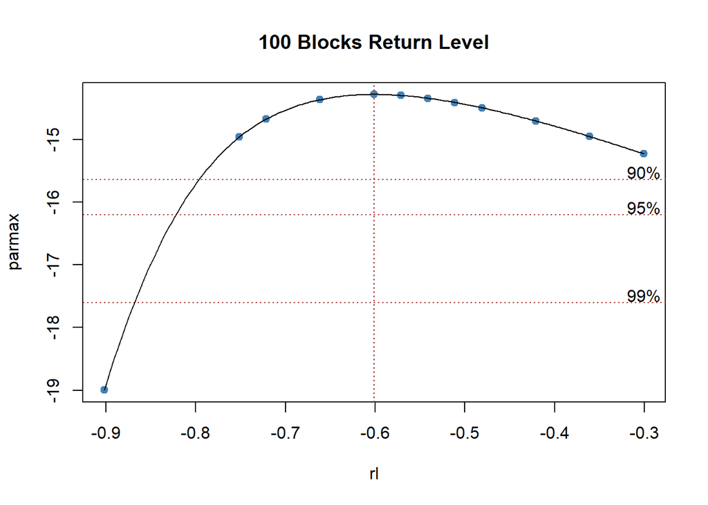

```
##                         min          v        max kBlocks
## GEV Return Level -0.7961365 -0.6012568 -0.3006284     100
```

```r
gevrlevelPlot(fitmle_gev_glass1,kBlocks = 100,  ci = c(0.90, 0.95, 0.99))
```

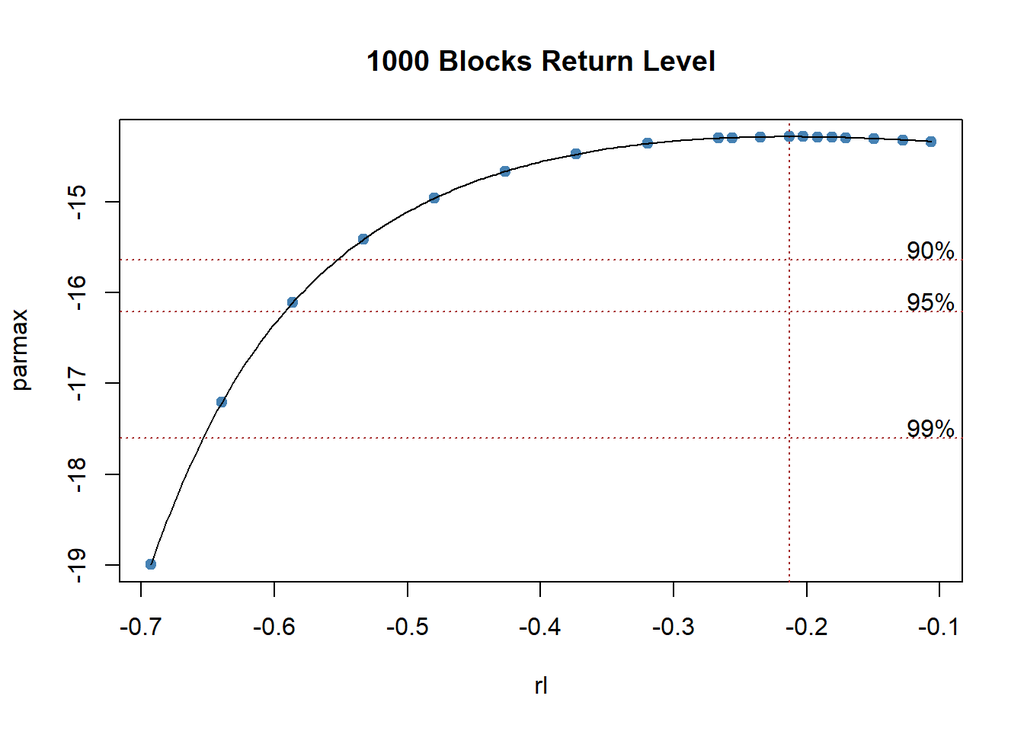

```
##                         min         v        max kBlocks
## GEV Return Level -0.5514317 -0.213181 -0.1065905    1000
```

```r
gevrlevelPlot(fitmle_gev_glass1,kBlocks = 1000,  ci = c(0.90, 0.95, 0.99))
```

## 4.8 Small conclusion

With a Weibull model we could estimate that the minimum strength once every 100 and 1000 breaking tests are respectively around 0.6 and 0.2 Newtons.Those results are consistent with the data since the minimum strength to break the glass was 0.55 Newtons.Yet the confidence interval is not good( for exemple for the 100 trials, the minimum strength confidence interval is [0,3;0,8]).Perhaps the problem here is that we do not have enough data (only 63 observations).